# Latihan 3 MPDW - Distributed Lag Model & ARDL

Rozan Al Hibrizi / M0401241096

2026-09-08

# Packages

```r
library(dLagM)
library(dynlm)
library(MLmetrics)
library(lmtest)
library(car)
```

# Latihan 1 : Distributed Lag Model (Pangsa Pasar vs Harga)

Diberikan data pangsa pasar (Y) dan harga (X) pasta gigi selama 20 periode. Akan dilakukan pemodelan *distributed lag* untuk melihat pengaruh harga terhadap pangsa pasar, kemudian dicari model terbaik dengan membandingkan model **Koyck** dan **Distributed Lag Model (DLM)**.

## Input Data

```r
Period <- 1:20
Y <- c(3.63, 4.20, 3.33, 4.54, 2.89, 4.87, 4.90, 5.29, 6.18, 7.20,
       7.25, 6.09, 6.80, 8.65, 8.43, 8.29, 7.18, 7.90, 8.45, 8.23)
X <- c(0.97, 0.95, 0.99, 0.91, 0.98, 0.90, 0.89, 0.86, 0.85, 0.82,
       0.79, 0.83, 0.81, 0.77, 0.76, 0.80, 0.83, 0.79, 0.76, 0.78)

data1 <- data.frame(Period, Y, X)
data1
```

```
##    Period    Y    X
## 1       1 3.63 0.97
## 2       2 4.20 0.95
## 3       3 3.33 0.99
## 4       4 4.54 0.91
## 5       5 2.89 0.98
## 6       6 4.87 0.90
## 7       7 4.90 0.89
## 8       8 5.29 0.86
## 9       9 6.18 0.85
## 10     10 7.20 0.82
## 11     11 7.25 0.79
## 12     12 6.09 0.83
## 13     13 6.80 0.81
## 14     14 8.65 0.77
## 15     15 8.43 0.76
## 16     16 8.29 0.80
## 17     17 7.18 0.83
## 18     18 7.90 0.79
## 19     19 8.45 0.76
## 20     20 8.23 0.78
```

## Eksplorasi Data

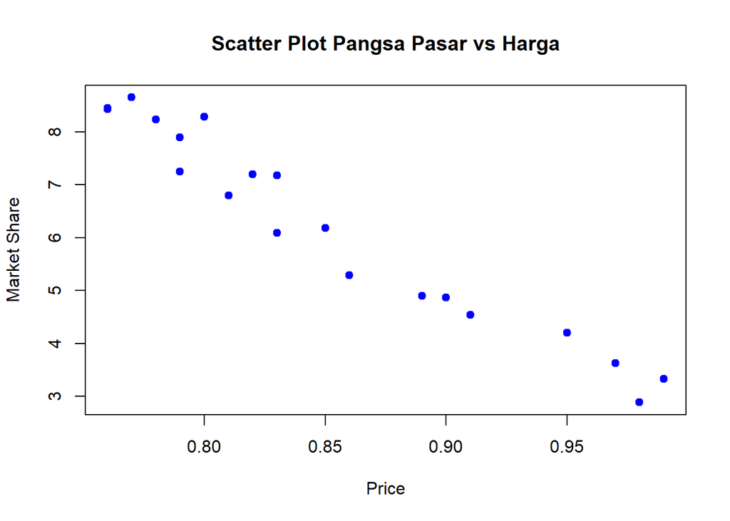

```r
plot(data1$X, data1$Y, type = "p", pch = 19, col = "blue",
     xlab = "Price", ylab = "Market Share",
     main = "Scatter Plot Pangsa Pasar vs Harga")
```

Pola scatter menunjukkan hubungan negatif antara harga dan pangsa pasar - semakin rendah harga, semakin tinggi pangsa pasar produk.

## Pembagian Data

Data dibagi menjadi 16 periode data training dan 4 periode data testing.

```r
data1_train <- data1[1:16, ]
data1_test  <- data1[17:20, ]
```

## Model Koyck

```r
model.koyck1 <- koyckDlm(x = data1_train$X, y = data1_train$Y)
summary(model.koyck1)
```

```
##
## Call:
## "Y ~ (Intercept) + Y.1 + X.t"
##
## Residuals:
##      Min       1Q   Median       3Q      Max
## -1.08831 -0.33583  0.03809  0.32369  1.08271
##
## Coefficients:
##             Estimate Std. Error t value Pr(>|t|)
## (Intercept)  14.1547    13.9055   1.018    0.329
## Y.1           0.4356     0.4547   0.958    0.357
## X.t         -12.4022    13.2392  -0.937    0.367
##
## Residual standard error: 0.6214 on 12 degrees of freedom
## Multiple R-Squared: 0.9013,  Adjusted R-squared: 0.8848
## Wald test: 42.97 on 2 and 12 DF,  p-value: 3.383e-06
##
## Diagnostic tests:
## NULL
##
##                             alpha      beta       phi
## Geometric coefficients:  25.08051 -12.40215 0.4356312
```

```r
AIC(model.koyck1)
```

```
## [1] 32.94998
```

```r
BIC(model.koyck1)
```

```
## [1] 35.78218
```

```r
fore.koyck1 <- forecast(model = model.koyck1, x = data1_test$X, h = 4)
fore.koyck1
```

```
## $forecasts
## [1] 7.472253 7.612103 8.045091 7.985671
##
## $call
## forecast.koyckDlm(model = model.koyck1, x = data1_test$X, h = 4)
##
## attr(,"class")
## [1] "forecast.koyckDlm" "dLagM"
```

```r
mape.koyck1.test  <- MAPE(fore.koyck1$forecasts, data1_test$Y)
mape.koyck1.train <- GoF(model.koyck1)$MAPE
mape.koyck1.test
```

```
## [1] 0.03868805
```

```r
mape.koyck1.train
```

```
## [1] 0.08947964
```